# ps5 Rmarkdown

Lisa Lu

2023-02-17

1.1-3

```r
library(readr)
library(stringr)
library(dplyr)
g <- read.delim("gapminder.csv")

nrow(g)
```

```
## [1] 13055
```

```r
ncol(g)
```

```
## [1] 25
```

```r
sample_n(g, 10)
```

```
##    iso3                               name iso2   region
## 1   BLZ                             Belize   BZ Americas
## 2   YEM                              Yemen   YE     Asia
## 3   BLR                            Belarus   BY   Europe
## 4   BMU                            Bermuda   BM Americas
## 5   SSD                        South Sudan   SS   Africa
## 6   GEO                            Georgia   GE     Asia
## 7   AZE                         Azerbaijan   AZ     Asia
## 8   IRQ                               Iraq   IQ     Asia
## 9   PNG                   Papua New Guinea   PG  Oceania
## 10  VEN Venezuela (Bolivarian Republic of)   VE Americas
##                         sub.region intermediate.region time totalPopulation
## 1  Latin America and the Caribbean     Central America 1977          136989
## 2                     Western Asia                     2017        27834821
## 3                   Eastern Europe                     2007         9560953
```

[output cut: 51 more lines]

It lists 10 random data for me and it looks alright for me.

2.1-3

```r
length(unique(g$iso3))
```

```
## [1] 253
```

```r
length(unique(g$iso2))
```

```
## [1] 249
```

```r
length(unique(g$name))
```

```
## [1] 250
```

```r
g %>%
  group_by(iso2) %>%
  summarise(n1 = n_distinct(name))
```

```
## # A tibble: 249 × 2
##    iso2     n1
##    <chr> <int>
##  1 ""        2
##  2 "AD"      1
##  3 "AE"      1
##  4 "AF"      1
##  5 "AG"      1
##  6 "AI"      1
##  7 "AL"      1
##  8 "AM"      1
##  9 "AO"      1
## 10 "AQ"      1
## # … with 239 more rows
```

```r
unique(g$name[g$iso2 == ""])
```

```
## [1] ""        "Namibia"
```

```r
g %>%
  group_by(name) %>%
  summarise(n2 = n_distinct(iso3))
```

```
## # A tibble: 250 × 2
##    name                     n2
##    <chr>                 <int>
##  1 ""                        4
##  2 "Afghanistan"             1
##  3 "Albania"                 1
##  4 "Algeria"                 1
##  5 "American Samoa"          1
##  6 "Andorra"                 1
##  7 "Angola"                  1
##  8 "Anguilla"                1
##  9 "Antarctica"              1
## 10 "Antigua and Barbuda"     1
## # … with 240 more rows
```

```r
unique(g$iso3[g$name == ""])
```

```
## [1] "CHANISL"     "GBM"         "KOS"         "NLD_CURACAO"
```

```r
min(g$time, na.rm = TRUE)
```

```
## [1] 1960
```

```r
max(g$time, na.rm = TRUE)
```

```
## [1] 2019
```

3.1

```r
a <- g %>%
  group_by(time) %>%
  filter(!is.na(time)) %>%
  summarise(n1 = length(is.na(co2)), n2 = length(is.na(co2_PC)), total = n1+n2)
a
```

```
## # A tibble: 60 × 4
##     time    n1    n2 total
##    <int> <int> <int> <int>
##  1  1960   216   216   432
##  2  1961   217   217   434
##  3  1962   217   217   434
##  4  1963   217   217   434
##  5  1964   217   217   434
##  6  1965   217   217   434
##  7  1966   217   217   434
##  8  1967   217   217   434
##  9  1968   217   217   434
## 10  1969   217   217   434
## # … with 50 more rows
```

```r
a$time[a$total == max(a$total)]
```

```
##  [1] 1961 1962 1963 1964 1965 1966 1967 1968 1969 1970 1971 1972 1973 1974 1975
## [16] 1976 1977 1978 1979 1980 1981 1982 1983 1984 1985 1986 1987 1988 1989 1990
## [31] 1991 1992 1993 1994 1995 1996 1997 1998 1999 2000 2001 2002 2003 2004 2005
## [46] 2006 2007 2008 2009 2010 2011 2012 2013 2014 2015 2016 2017 2018 2019
```

3.2

```r
library(tidyverse)
```

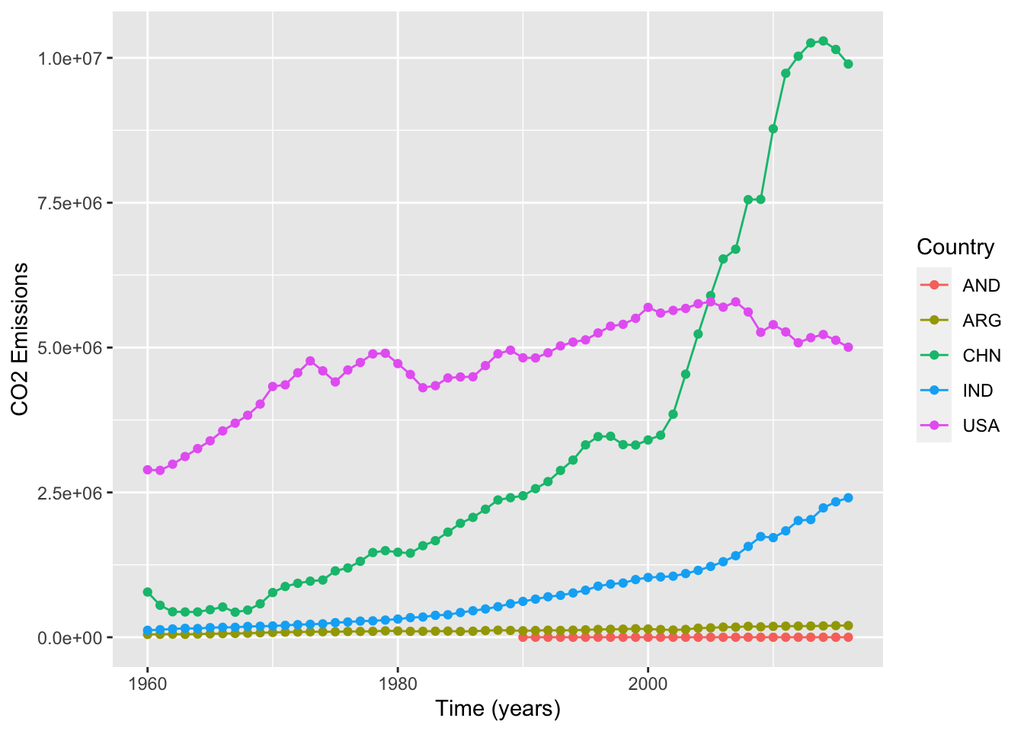

```r
g %>%
  filter(!is.na(co2)) %>%
  filter(iso3 == "USA" | iso3 == "CHN" | iso3 == "IND" | iso3 == "AND" |
           iso3 == "ARG") %>%


ggplot(aes(time, co2, col=factor(iso3))) +
  geom_line() +
  geom_point() +
  labs(x = "Time (years)", y = "CO2 Emissions",
       col = "Country")
```

I see that China has increased CO2 emissions drastically compared to other countries. The U.S.is trying to decrease CO2 emissions in recent years, and the use of CO2 in India have been increasing constantly. CO2 emissions in Argentina and Andorra is neither increasing nor decreasing and they always remain at the same level.

3.3

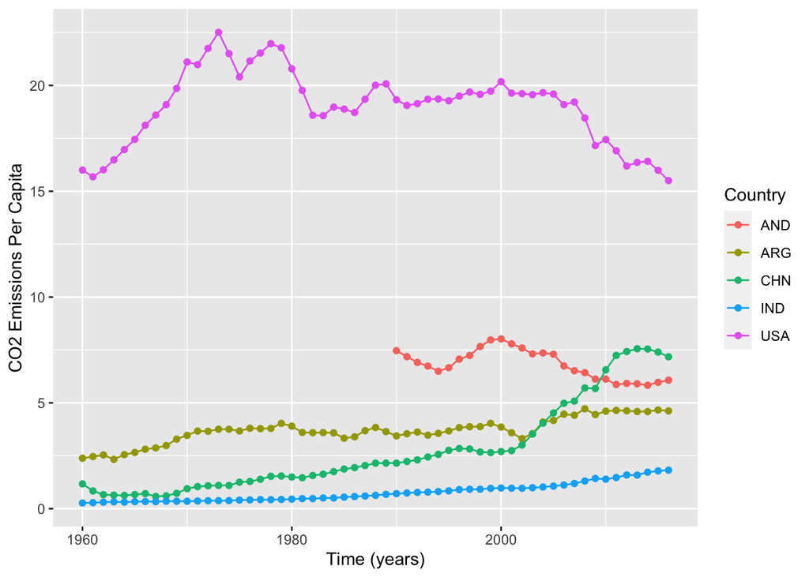

```r
g %>%
  filter(!is.na(co2)) %>%
  filter(iso3 == "USA" | iso3 == "CHN" | iso3 == "IND" | iso3 == "AND" |
           iso3 == "ARG") %>%

ggplot(aes(time, co2_PC, col=factor(iso3))) +
  geom_line() +
  geom_point() +
  labs(x = "Time (years)", y = "CO2 Emissions Per Capita",
       col = "Country")
```

3.4

```r
g %>%
  filter(!is.na(co2_PC)) %>%
  group_by(time, region) %>%
  summarize(n= mean(co2_PC))
```

```
## # A tibble: 294 × 3
## # Groups:   time [57]
##     time region       n
##    <int> <chr>    <dbl>
##  1  1960 Africa   0.291
##  2  1960 Americas 7.15
##  3  1960 Asia     1.74
##  4  1960 Europe   5.77
##  5  1960 Oceania  2.73
##  6  1961 Africa   0.300
##  7  1961 Americas 7.38
##  8  1961 Asia     2.06
##  9  1961 Europe   5.92
## 10  1961 Oceania  2.85
## # … with 284 more rows
```

This shows the mean of CO2 emissions per capita each continent release each year. In this chart we can observe the difference and whether there is an increase or decrease in different continents with their average CO2 emissions per capita.

3.5

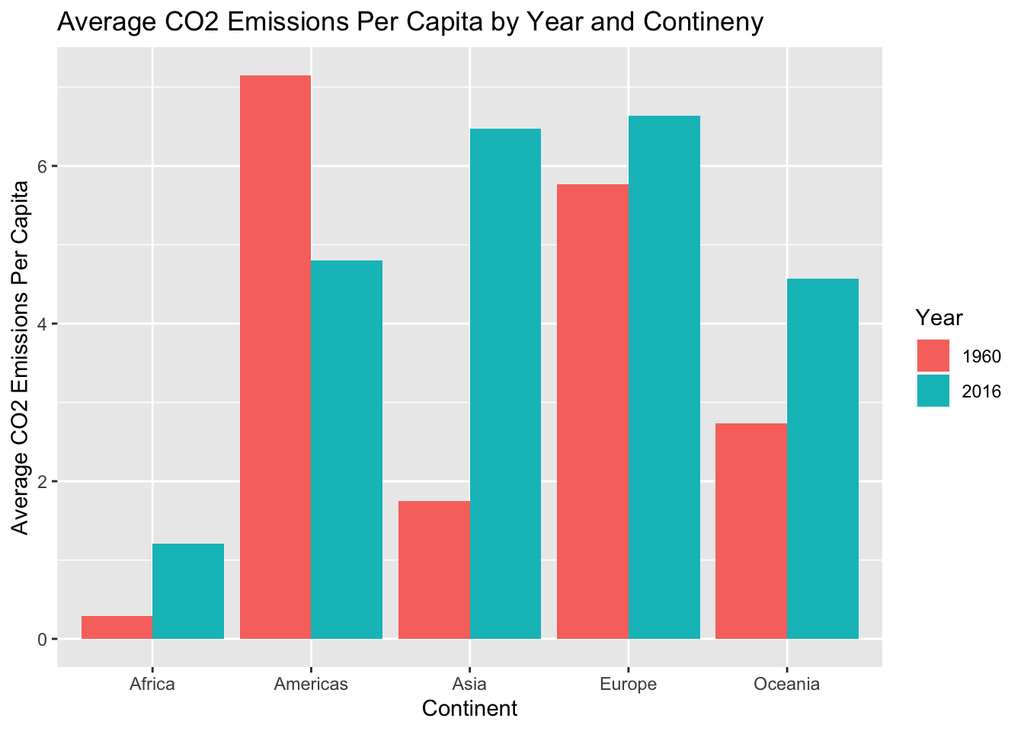

```r
g %>%
  filter(time == 1960 | time ==2016, !is.na(co2_PC), !is.na(region)) %>%
  filter(region != "") %>%
  group_by(time, region) %>%
  summarise(avg_co2PC = mean(co2_PC), .groups = "drop") %>%
  ggplot(aes(x = region, y = avg_co2PC, fill = as.factor(time))) +
  geom_col(position = "dodge") +
    labs(title = "Average CO2 Emissions Per Capita by Year and Contineny",
         x = "Continent",
         y = "Average CO2 Emissions Per Capita") +
  scale_fill_discrete(name = "Year")
```

3.6

```r
g %>%
  filter(!is.na(co2_PC), time == 2016,  region != "") %>%
  group_by(region, name) %>%
  summarise(avg_co2pc = mean(co2_PC), .groups = "drop") %>%
  arrange(region, avg_co2pc) %>%
  group_by(region) %>%
  head(3) %>%
  select(region, name, avg_co2pc)
```

```
## # A tibble: 3 × 3
## # Groups:   region [1]
##   region name                              avg_co2pc
##   <chr>  <chr>                                 <dbl>
## 1 Africa Congo, Democratic Republic of the    0.0256
## 2 Africa Somalia                              0.0455
## 3 Africa Burundi                              0.0472
```

4.1

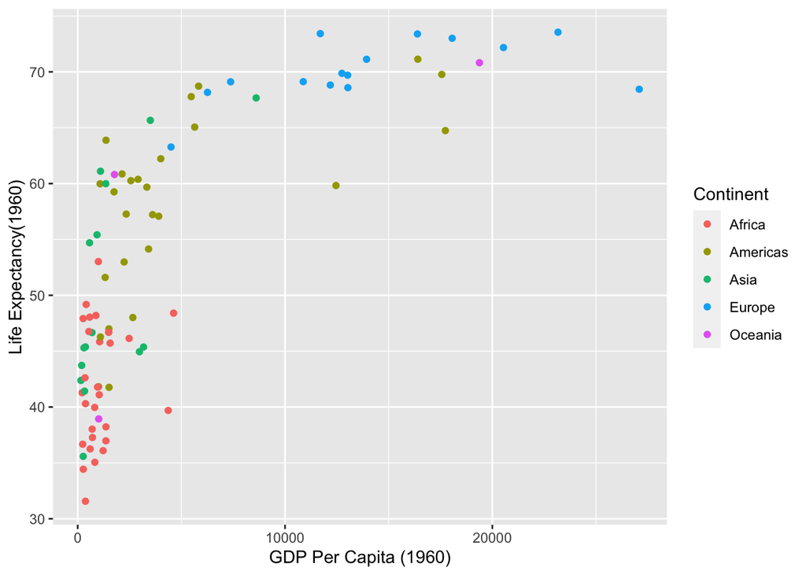

```r
g %>%
  filter(time == 1960) %>%
  filter(!is.na(GDP_PC), !is.na(lifeExpectancy), !is.na(region)) %>%
ggplot(aes(GDP_PC, lifeExpectancy, col=factor(region))) +
  geom_point() +
  labs(x = "GDP Per Capita (1960)", y = "Life Expectancy(1960)",
       col = "Continent")
```

This plot shows that European countries regardless of their GDP per capita overall have higher life expectancy. Africa, Asia, and Americas overall have lower GDP per capita but Americas and Asia have slightly higher life expectancy compared to Africa.

4.2

[figure not shown]

```r
g %>%
  filter(time == 2019) %>%
  filter(!is.na(GDP_PC), !is.na(lifeExpectancy), !is.na(region), region != "") %>%
ggplot(aes(GDP_PC, lifeExpectancy, col=factor(region))) +
  geom_point() +
  labs(x = "GDP Per Capita (2016)", y = "Life Expectancy(2016)",
       col = "Continent")
```

4.3. Countries have been stabilized in the similar positions where Europe is still at the top and Africa at the bottom. The only obvious changes as we can see is that people live longer than they were 60 years ago and that there is a drastic increase in GDP per capita too.

4.4

```r
g %>%
  filter(!is.na(lifeExpectancy), region !="") %>%
  group_by(region, time) %>%
  filter(time == 1960 | time == 2019) %>%
  summarise(n = mean(lifeExpectancy))
```

```
## # A tibble: 10 × 3
## # Groups:   region [5]
##    region    time     n
##    <chr>    <int> <dbl>
##  1 Africa    1960  41.5
##  2 Africa    2019  64.1
##  3 Americas  1960  58.6
##  4 Americas  2019  75.8
##  5 Asia      1960  51.6
##  6 Asia      2019  74.6
##  7 Europe    1960  68.3
##  8 Europe    2019  79.4
##  9 Oceania   1960  56.4
## 10 Oceania   2019  73.5
```

4.5

```r
g %>%
  filter(time == 1960 | time == 2019) %>%
  filter(!is.na(region), !is.na(lifeExpectancy), region != "") %>%
  group_by(region, time) %>%
  summarise(avr = mean(lifeExpectancy), .groups = "drop") %>%
  group_by(region) %>%
  mutate(pre = lag(avr), growth = avr - pre) %>%
  filter(!is.na(pre)) %>%
  arrange(growth)
```

```
## # A tibble: 5 × 5
## # Groups:   region [5]
##   region    time   avr   pre growth
##   <chr>    <int> <dbl> <dbl>  <dbl>
## 1 Europe    2019  79.4  68.3   11.1
## 2 Oceania   2019  73.5  56.4   17.1
## 3 Americas  2019  75.8  58.6   17.2
## 4 Africa    2019  64.1  41.5   22.6
## 5 Asia      2019  74.6  51.6   23.0
```

4.6

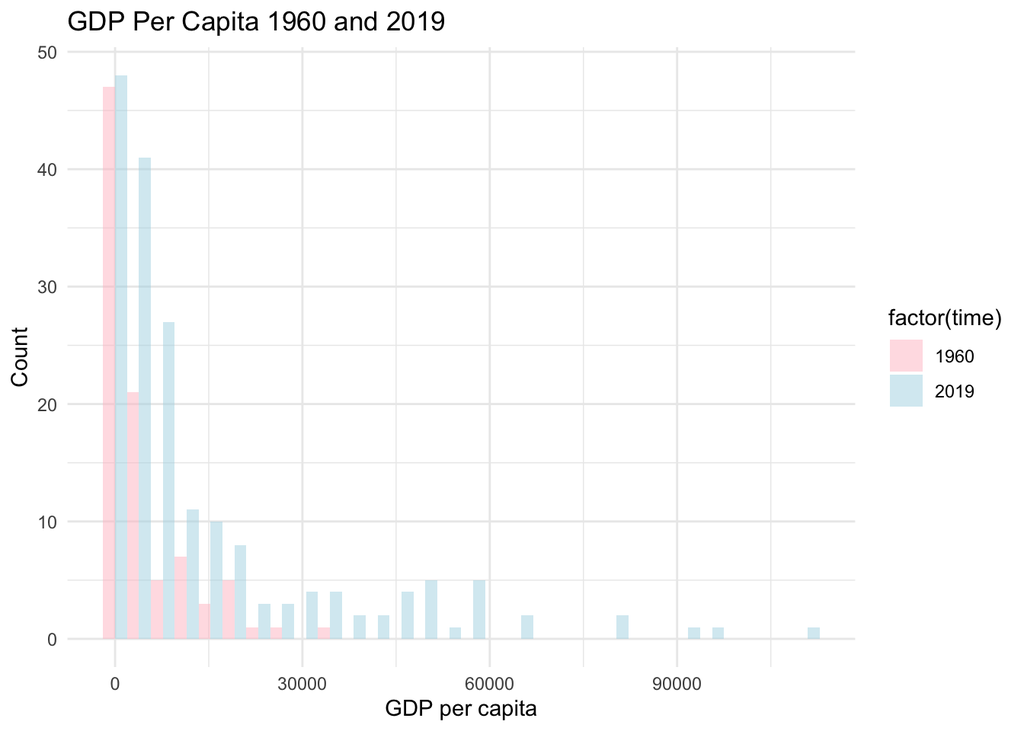

```r
g %>%
  filter(!is.na(GDP_PC), time %in% c(1960, 2019)) %>%
  ggplot(aes(x = GDP_PC, fill = factor(time))) +
  geom_histogram(alpha = 0.5, position = "dodge", bins = 30) +
  scale_fill_manual(values = c("pink", "lightblue"), labels =
c("1960", "2019")) +
  labs(x = "GDP per capita", y = "Count", title = "GDP Per Capita 1960 and 2019") +
  theme_minimal()
```

4.7

```r
g %>%
  select(name, time, lifeExpectancy) %>%
  filter(name !="", !is.na(time), !is.na(lifeExpectancy)) %>%
  filter(time == "1960") %>%
  mutate(rank = rank(desc(lifeExpectancy))) %>%
  filter(name == "United States of America")
```

```
##                       name time lifeExpectancy rank
## 1 United States of America 1960       69.77073   17
```

```r
g %>%
  select(name, time, lifeExpectancy) %>%
  filter(name !="", !is.na(time), !is.na(lifeExpectancy)) %>%
  filter(time == "2019") %>%
  mutate(rank = rank(desc(lifeExpectancy))) %>%
  filter(name == "United States of America")
```

```
##                       name time lifeExpectancy rank
## 1 United States of America 2019        78.7878   46
```

4.8

```r
g %>%
  select(name, time, lifeExpectancy) %>%
  filter(name !="", !is.na(time), !is.na(lifeExpectancy)) %>%
  group_by(time) %>%
  mutate(rank = rank(desc(lifeExpectancy)), num = length(name)) %>%
  filter(name == "United States of America") %>%
  mutate(r = rank/num)
```

```
## # A tibble: 60 × 6
## # Groups:   time [60]
##    name                      time lifeExpectancy  rank   num      r
##    <chr>                    <int>          <dbl> <dbl> <int>  <dbl>
##  1 United States of America  1960           69.8    17   188 0.0904
##  2 United States of America  1961           70.3    14   189 0.0741
##  3 United States of America  1962           70.1    17   189 0.0899
##  4 United States of America  1963           69.9    20   188 0.106
##  5 United States of America  1964           70.2    22   188 0.117
##  6 United States of America  1965           70.2    21   189 0.111
##  7 United States of America  1966           70.2    26   189 0.138
##  8 United States of America  1967           70.6    21   189 0.111
##  9 United States of America  1968           70.0    32   189 0.169
## 10 United States of America  1969           70.5    25   189 0.132
## # … with 50 more rows
```

Bruh it took me a long time to do it, maybe I don’t know, so many days total, more than 20 hours